Model used Simple Linear regression Reason: We only have 2 numerical features which is correlated to each other so the Simple linear regression is used.

Register No: 21MIS1044 Name: Srinivasan JP

```python
#imports

import pandas as pd
import seaborn as sn
from sklearn.model_selection import train_test_split
import matplotlib.pyplot as plt
from sklearn.linear_model import LinearRegression
import numpy as np
from sklearn.metrics import mean_squared_error, r2_score
```

```python
# Creating pandas DataFrame from the CSV file
marketing = pd.read_csv("tvmarketing.csv")
```

```python
df = pd.DataFrame(marketing)
print(df.head())
```

```
      TV  Sales
0  230.1   22.1
1   44.5   10.4
2   17.2    9.3
3  151.5   18.5
4  180.8   12.9
```

```python
#Pre-processing filling the empty cells
df['TV'].fillna(df['TV'].mean(), inplace=True)
df['Sales'].fillna(df['Sales'].mean(), inplace=True)
print(df.head())
```

```
      TV  Sales
0  230.1   22.1
1   44.5   10.4
2   17.2    9.3
3  151.5   18.5
4  180.8   12.9
```

In TV column all the empty cells are filled with the mean of the same column In Sales column also the same process the empty cells are filled with the mean of the Sales column

Finding the correlation between the two column

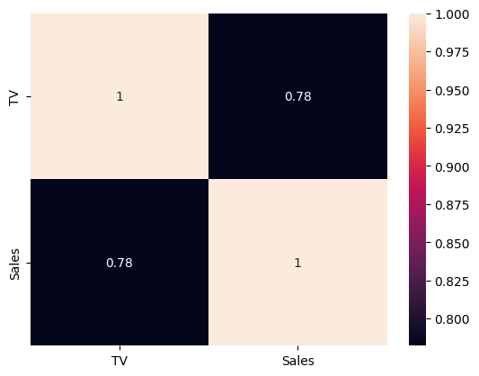

```python
corr_matrix = df.corr()
sn.heatmap(corr_matrix, annot=True)
plt.show()
```

Spliting the test and train data with the help of sklearn module train dataset contains 70% of the data and test dataset has 30% of the data

```python
X = df['TV']
y = df["Sales"]
X_train, X_test, y_train, y_test = train_test_split(X, y, train_size=0.7 , random_state=0000)
```

```python
#Simply put, numpy.newaxis is used to increase the dimension of the existing array by one more dimension,
X_train = X_train[:, np.newaxis]
X_test = X_test[:, np.newaxis]
```

```python
lr = LinearRegression()

# Fit the model using lr.fit()
lr.fit(X_train, y_train)
print(lr.intercept_)
print(lr.coef_)
```

```
7.310810165411681
[0.04581434]
```

Fitting the training dataset to the LinearRegression model to train the model then we can easily print the intercept and coeffecient of the model

we got model : Y = 0.0458 X + 7.31

By using the model the test dataset is predicted the graph is plotted using the test and predicted y values

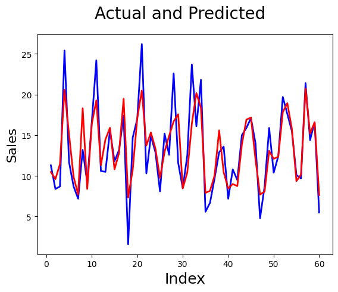

```python
y_pred = lr.predict(X_test)
c = [i for i in range(1,61,1)]         # generating index
fig = plt.figure()
plt.plot(c,y_test, color="blue", linewidth=2, linestyle="-")
plt.plot(c,y_pred, color="red",  linewidth=2, linestyle="-")
fig.suptitle('Actual and Predicted', fontsize=20)              # Plot heading
plt.xlabel('Index', fontsize=18)                               # X-label
plt.ylabel('Sales', fontsize=16)                       # Y-label
```

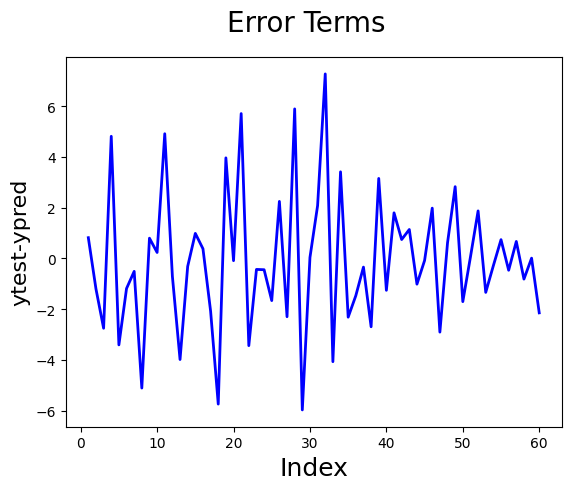

```python
c = [i for i in range(1,61,1)]
fig = plt.figure()
plt.plot(c,y_test-y_pred, color="blue", linewidth=2, linestyle="-")
fig.suptitle('Error Terms', fontsize=20)              # Plot heading
plt.xlabel('Index', fontsize=18)                      # X-label
plt.ylabel('ytest-ypred', fontsize=16)
```

```python
#Calculating the Mean Squared Error and R-Squared value
mse = mean_squared_error(y_test, y_pred)
r_squared = r2_score(y_test, y_pred)
print('Mean_Squared_Error :' ,mse)
print('r_square_value :',r_squared)
```

```
Mean_Squared_Error : 7.497479593464674
r_square_value : 0.725606346597073
```

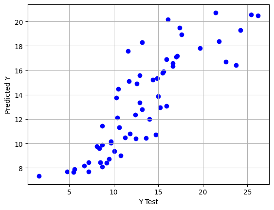

```python
plt.scatter(y_test,y_pred,c='blue')
plt.xlabel('Y Test')
plt.ylabel('Predicted Y')
plt.grid()
```